# Lesson 3

### What to Do First?

Notes:

### Pseudo-Facebook User Data

Notes:

```r
getwd()
```

```
## [1] "/Users/ameinert/R_projects/class_data_analytics/week3"
```

```r
knitr::opts_chunk$set(echo = TRUE)
fb_data <- read.csv("~/R_projects/class_data_analytics/data/pseudo_facebook.tsv", sep = "\t")
```

```r
head(fb_data)
```

```
##    userid age dob_day dob_year dob_month gender tenure friend_count
## 1 2094382  14      19     1999        11   male    266            0
## 2 1192601  14       2     1999        11 female      6            0
## 3 2083884  14      16     1999        11   male     13            0
## 4 1203168  14      25     1999        12 female     93            0
## 5 1733186  14       4     1999        12   male     82            0
## 6 1524765  14       1     1999        12   male     15            0
##   friendships_initiated likes likes_received mobile_likes
## 1                     0     0              0            0
## 2                     0     0              0            0
## 3                     0     0              0            0
## 4                     0     0              0            0
## 5                     0     0              0            0
## 6                     0     0              0            0
##   mobile_likes_received www_likes www_likes_received
## 1                     0         0                  0
## 2                     0         0                  0
## 3                     0         0                  0
## 4                     0         0                  0
## 5                     0         0                  0
## 6                     0         0                  0
```

### Histogram of Users’ Birthdays

Notes:

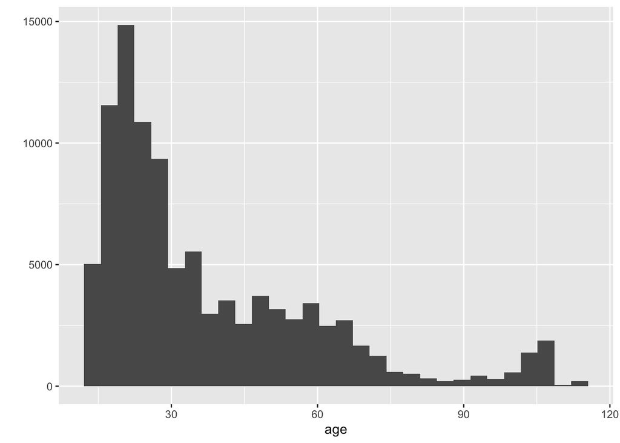

```r
#install.packages('ggplot2')
library(ggplot2)

qplot(data = fb_data, x=age)
```

```r
quantile(fb_data$age)
```

```
##   0%  25%  50%  75% 100%
##   13   20   28   50  113
```

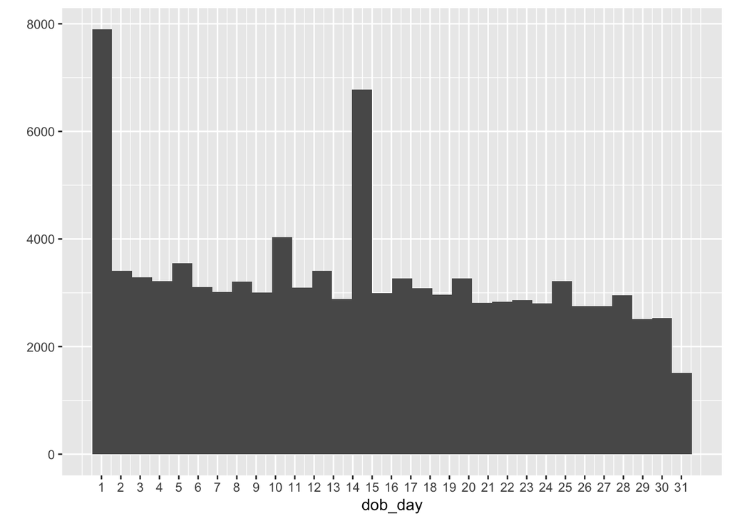

```r
qplot(data = fb_data, x=dob_day) +
   scale_x_continuous(breaks=1:31)
```

#### What are some things that you notice about this histogram?

Response: dob on the 1th of a month is very frequent, also the 15th. the 31th seems under-representeted. interpretation: not every month has 31 days, so the under-represention of 31th is realistic. the 1th of a month is not very intuitiv - maybe false input for day of birth? same with 15th

### Moira’s Investigation

Notes: Moira investigation is about quantification of audience size. her findings is that most users underestimates their size of audience.

### Estimating Your Audience Size

Notes:

#### Think about a time when you posted a specific message or shared a photo on Facebook. What was it?

Response:

#### How many of your friends do you think saw that post?

Response:

#### Think about what percent of your friends on Facebook see any posts or comments that you make in a month. What percent do you think that is?

Response:

### Perceived Audience Size

Notes:

### Faceting

Notes:

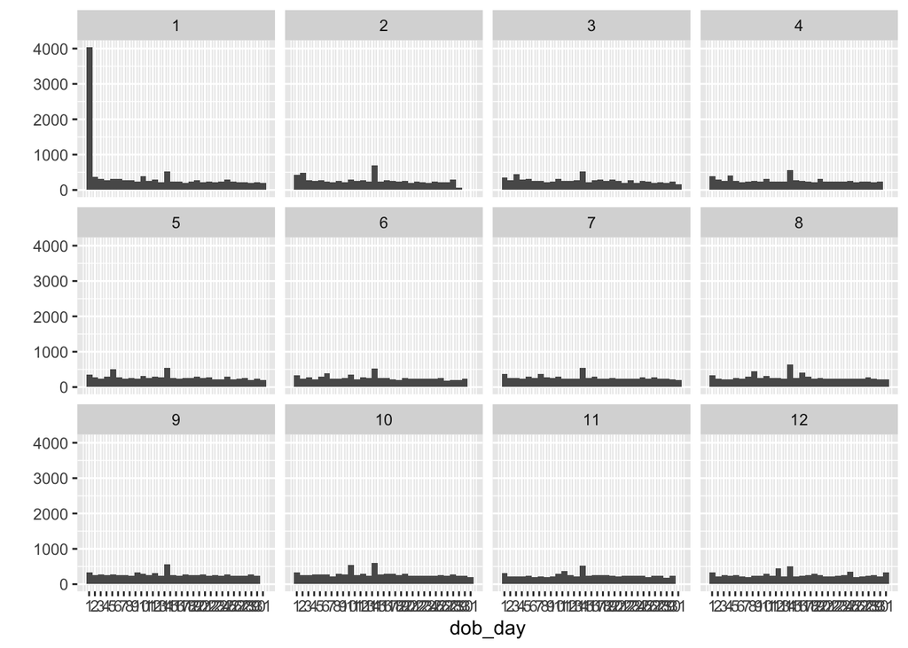

```r
qplot(data = fb_data, x = dob_day) +
  scale_x_continuous(breaks = 1:31) +
  facet_wrap(~dob_month)
```

#### Let???s take another look at our plot. What stands out to you here?

Response: the 01.01. is overrepresentated. it seems that my assumpation about fake dob input is more realistic, because its the default input of the dropdown menue

### Be Skeptical - Outliers and Anomalies

Notes:

### Moira’s Outlier

Notes: #### Which case do you think applies to Moira???s outlier? Response:

### Friend Count

Notes:

#### What code would you enter to create a histogram of friend counts?

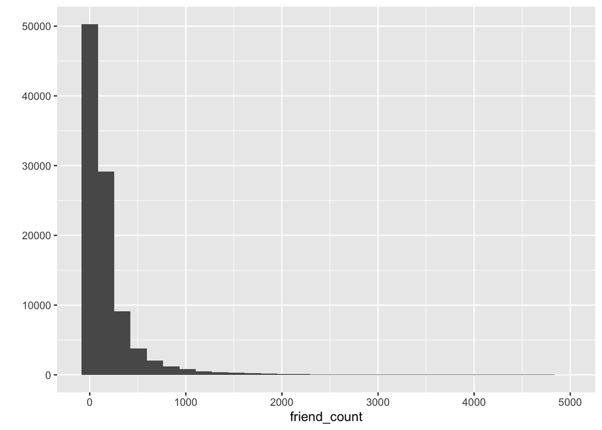

```r
qplot(data=fb_data, x= friend_count)
```

#### what is the plot looks like?

Response: the variable distribution is squished into the lower section this distrubtion called “long tail” data

### Limiting the Axes

Notes:

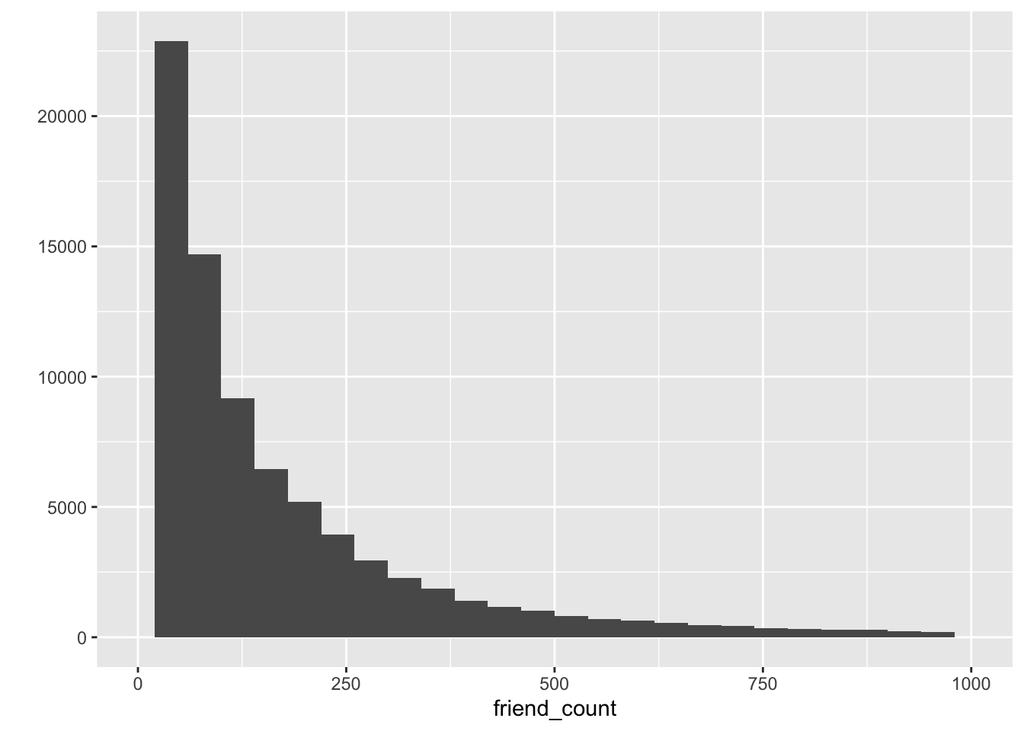

```r
qplot(data=fb_data, x= friend_count, binwidth = 40) +
  scale_x_continuous(limits=c(1,1000))
```

```r
#qplot(data=fb_data, x= friend_count, xlim=c(0,1000), binwidth = 40)
```

### Exploring with Bin Width

Notes:

### Adjusting the Bin Width

Notes:

### Faceting Friend Count

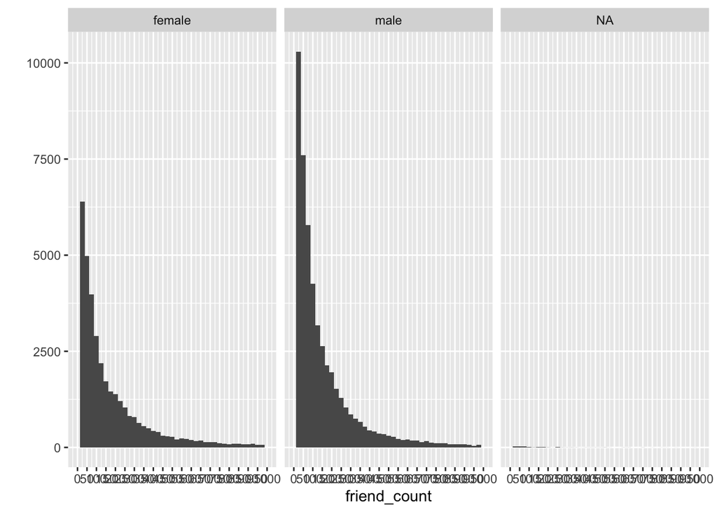

```r
# What code would you add to create a facet the histogram by gender?
# Add it to the code below.
qplot(x = friend_count, data = fb_data, binwidth = 25) +
  scale_x_continuous(limits = c(0, 1000),
                     breaks = seq(0, 1000, 50)) +
  facet_wrap(~gender)
```

### Omitting NA Values

Notes:

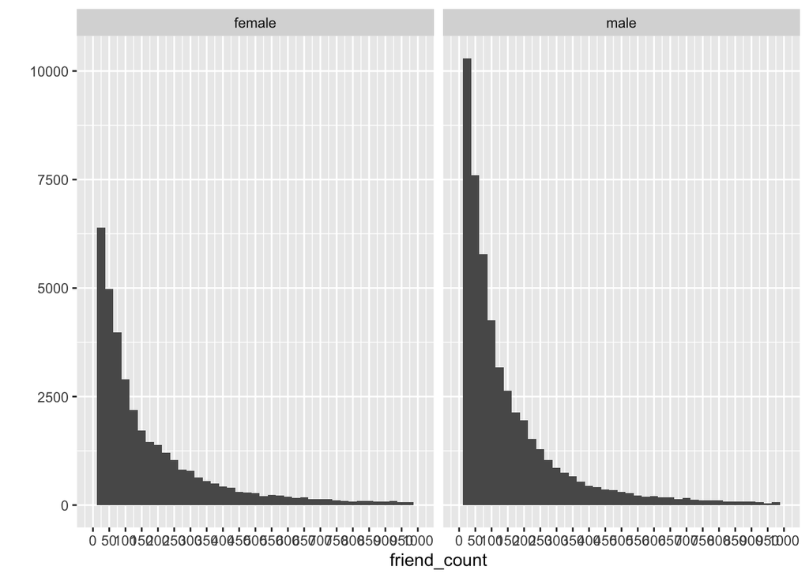

```r
qplot(x = friend_count, data = na.omit(fb_data), binwidth = 25) +
  scale_x_continuous(limits = c(0, 1000),
                     breaks = seq(0, 1000, 50)) +
  facet_wrap(~gender)
```

### Statistics ‘by’ Gender

Notes:

```r
table(fb_data$gender)
```

```
##
## female   male
##  40254  58574
```

```r
by(fb_data$friend_count, fb_data$gender, mean)
```

```
## fb_data$gender: female
## [1] 241.9699
## --------------------------------------------------------
## fb_data$gender: male
## [1] 165.0355
```

```r
by(fb_data$friend_count, fb_data$gender, summary)
```

```
## fb_data$gender: female
##    Min. 1st Qu.  Median    Mean 3rd Qu.    Max.
##       0      37      96     242     244    4923
## --------------------------------------------------------
## fb_data$gender: male
##    Min. 1st Qu.  Median    Mean 3rd Qu.    Max.
##       0      27      74     165     182    4917
```

#### Who on average has more friends: men or women?

Response: mean female: 241.9699 mean male: 165.0355

#### Why would the median be a better measure than the mean?

Response: its robust against extreme values (outlier). median < mean is because of the long tail distribution

### Tenure

Notes:

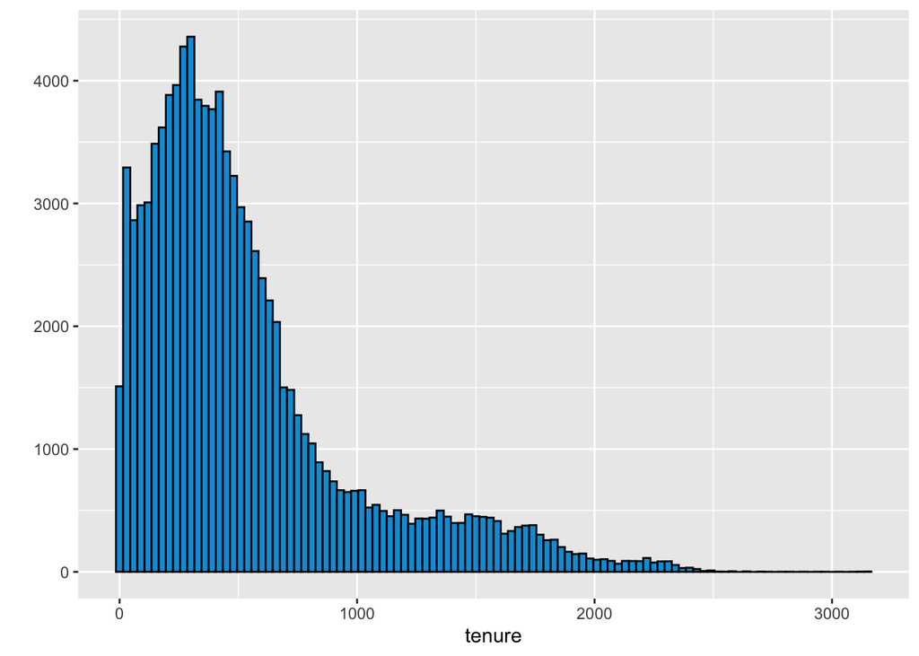

```r
qplot(data = fb_data, x = tenure, binwidth = 30, color = I('black'), fill = I('#099DD9'))
```

#### How would you create a histogram of tenure by year?

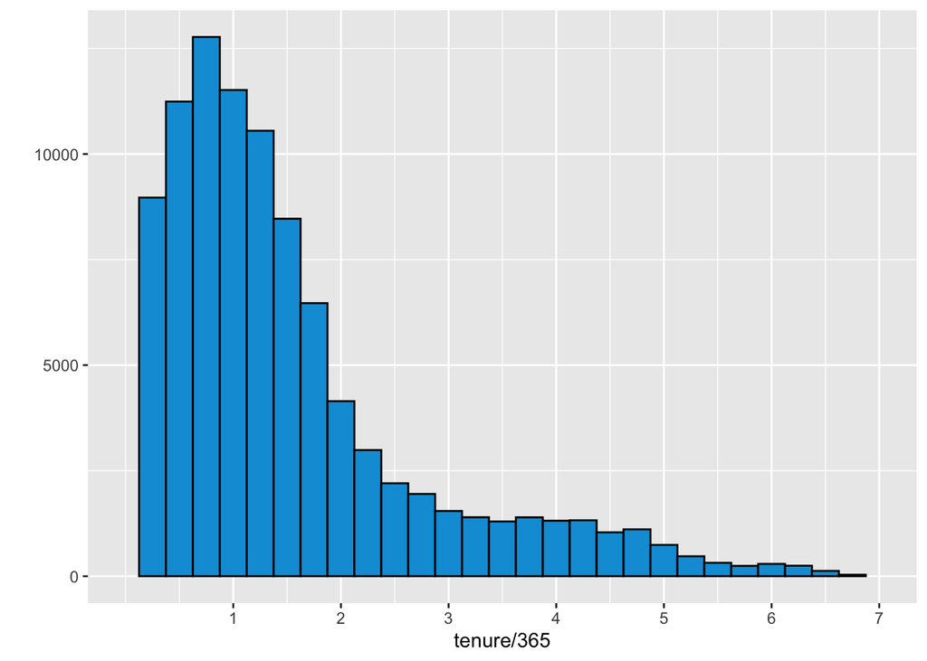

```r
qplot(data = fb_data, x = tenure/365, binwidth = 0.25, color = I('black'), fill = I('#099DD9'))+
  scale_x_continuous(limits = c(0,7),  breaks = seq(1,7,1))
```

### Labeling Plots

Notes:

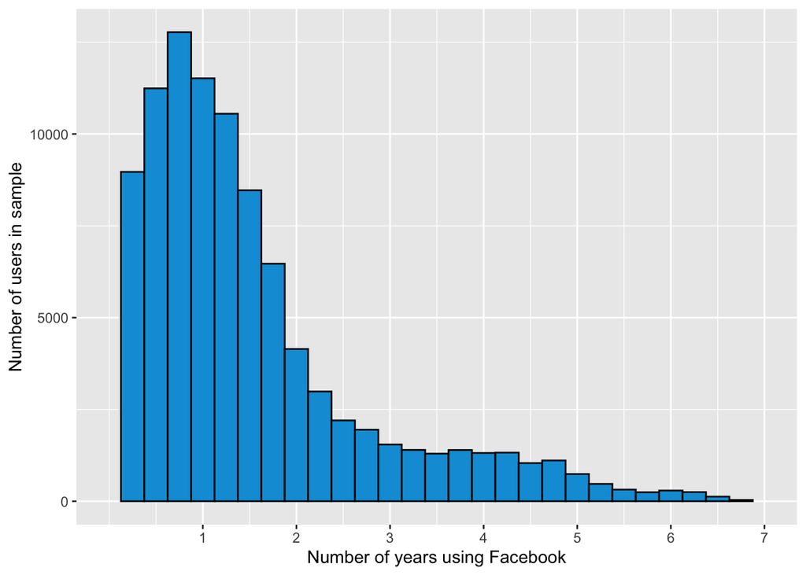

```r
qplot(data = fb_data, x = tenure/365, binwidth = 0.25, color = I('black'), fill = I('#099DD9'))+
  scale_x_continuous(limits = c(0,7),  breaks = seq(1,7,1))+
  xlab('Number of years using Facebook') +
  ylab('Number of users in sample')
```

### User Ages

Notes:

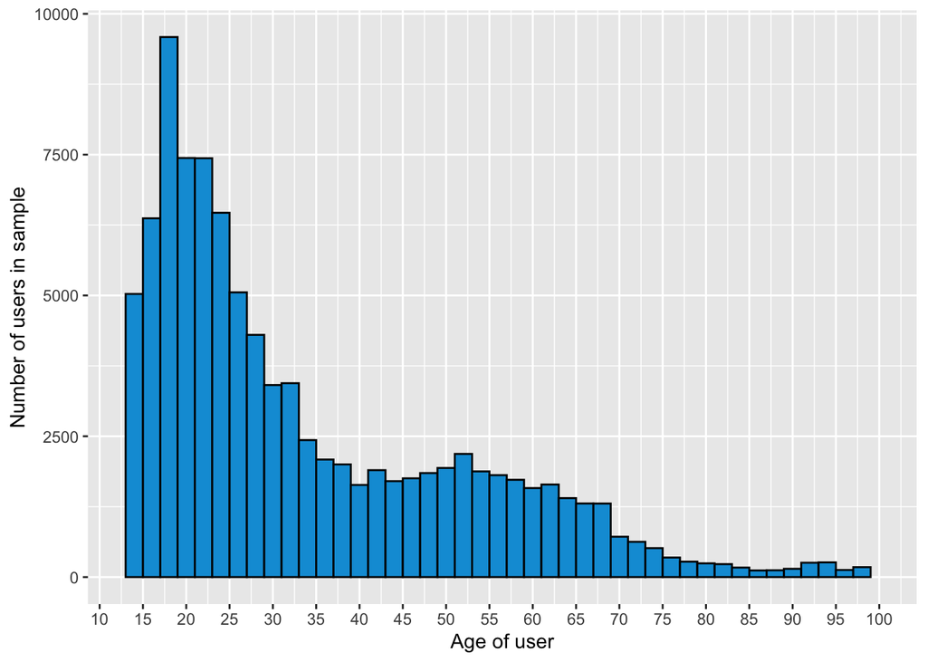

```r
qplot(data = fb_data, x = age, binwidth = 2, color = I('black'), fill = I('#099DD9'))+
  scale_x_continuous(limits = c(min(fb_data$age),100), breaks= seq(10, 100, 5))+
  xlab('Age of user') +
  ylab('Number of users in sample')
```

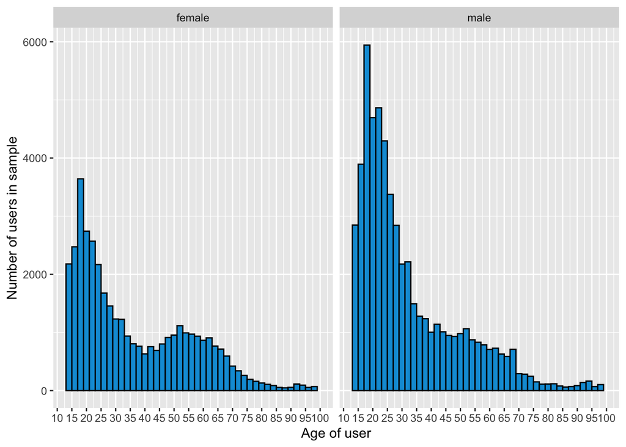

```r
qplot(data = na.omit(fb_data), x = age, binwidth = 2, color = I('black'), fill = I('#099DD9'))+
  scale_x_continuous(limits = c(min(fb_data$age),100), breaks= seq(10, 100, 5))+
  xlab('Age of user') +
  ylab('Number of users in sample') +
  facet_wrap(~gender)
```

#### What do you notice?

Response:

### The Spread of Memes

Notes:

### Lada’s Money Bag Meme

Notes:

### Transforming Data

Notes:

### Scaling x axis with transforming x

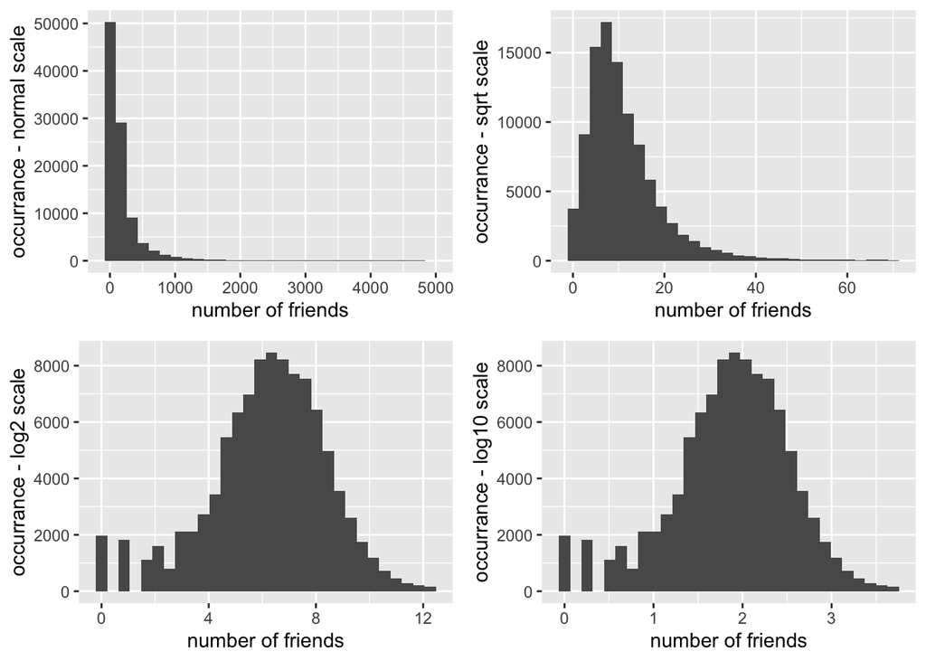

```r
#install.packages("gridExtra")
library(gridExtra)

# define individual plots
p1 = qplot(data = fb_data, x=friend_count) +
  xlab('number of friends') +
  ylab('occurrance - normal scale')
p2 = qplot(data = fb_data, x=sqrt(friend_count)) +
  xlab('number of friends') +
  ylab('occurrance - sqrt scale')
p3 = qplot(data = fb_data, x=log2(friend_count+1)) +
  xlab('number of friends') +
  ylab('occurrance - log2 scale')
p4 = qplot(data = fb_data, x=log10(friend_count+1))+
  xlab('number of friends') +
  ylab('occurrance - log10 scale')

# arrange plots in grid
grid.arrange(p1, p2, p3, p4 , ncol=2)
```

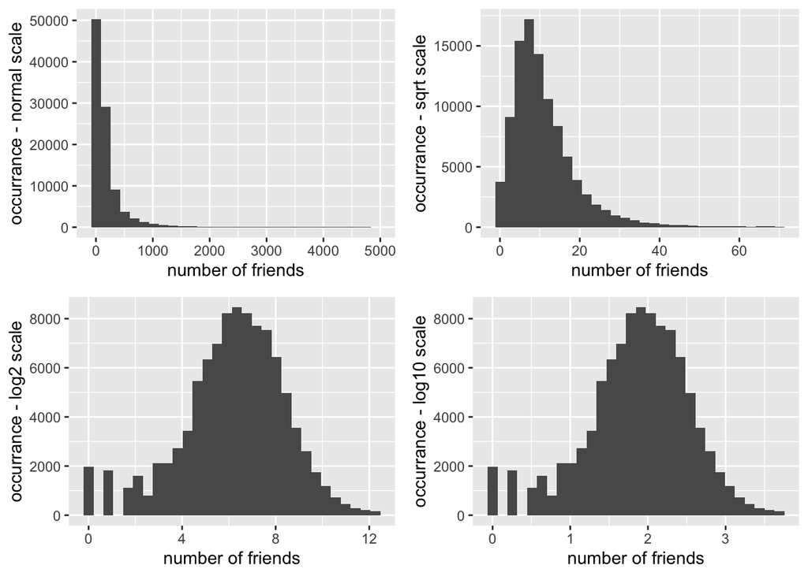

```r
#install.packages("gridExtra")
library(gridExtra)

# define individual plots
p5 = qplot(data = fb_data, x=friend_count) +
  xlab('number of friends') +
  ylab('occurrance - normal scale')
p6 = qplot(data = fb_data, x=friend_count) +
  scale_x_continuous(trans='sqrt') +
  xlab('number of friends') +
  ylab('occurrance - sqrt scale')
p7 = qplot(data = fb_data, x=friend_count+1) +
  scale_x_continuous(trans='log2') +
  xlab('number of friends') +
  ylab('occurrance - log2 scale')
p8 = qplot(data = fb_data, x=friend_count+1) +
  scale_x_continuous(trans='log10')+
  xlab('number of friends') +
  ylab('occurrance - log10 scale')

# arrange plots in grid
grid.arrange(p1, p2, p3, p4 , ncol=2)
```

### difference:

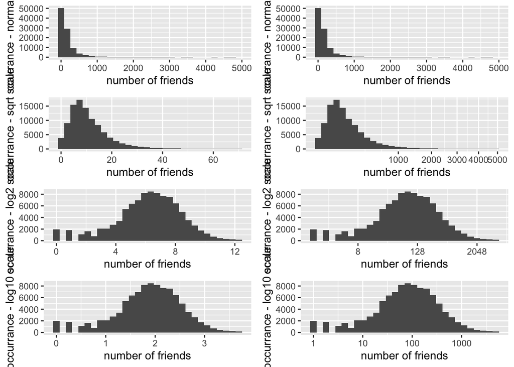

```r
# arrange plots in grid
grid.arrange(p1, p5, p2, p6, p3, p7, p4, p8, ncol=2)
```

### Frequency Polygons

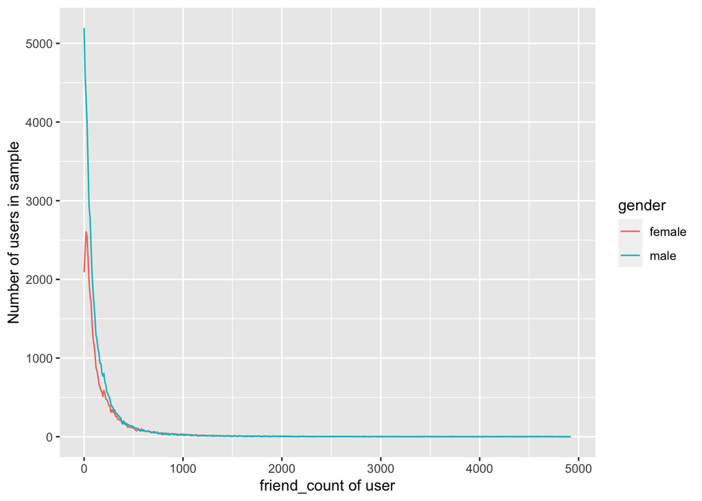

```r
qplot(data = na.omit(fb_data), x = friend_count, binwidth = 10, color = gender, geom = "freqpoly")+
  scale_x_continuous(limits = c(min(fb_data$friend_count),max(fb_data$friend_count)))+
  xlab('friend_count of user') +
  ylab('Number of users in sample')
```

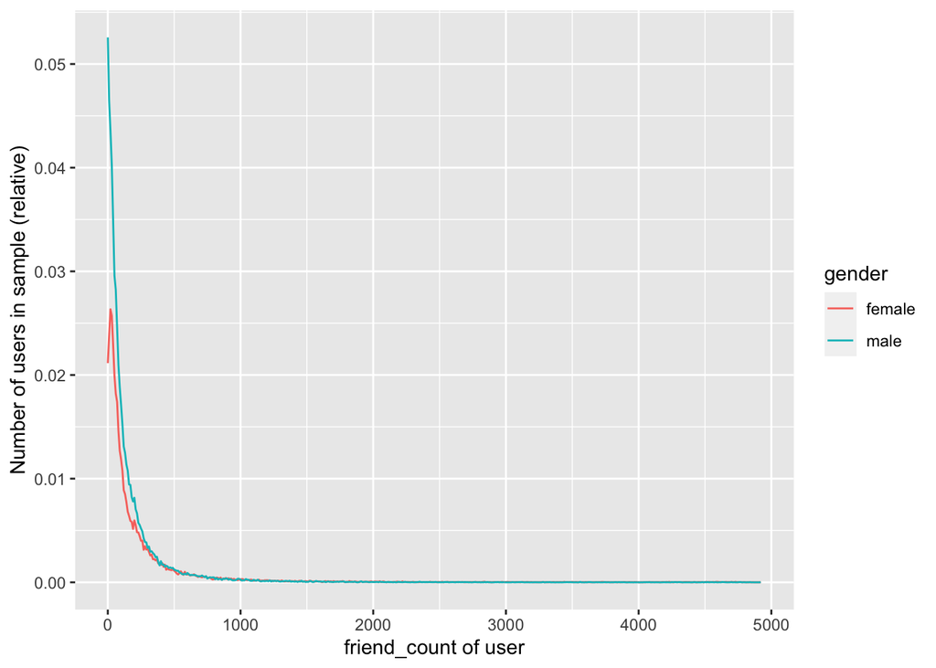

```r
qplot(data = na.omit(fb_data), x = friend_count, y=..count../sum(..count..), binwidth = 10, color = gender, geom = "freqpoly")+
  scale_x_continuous(limits = c(min(fb_data$friend_count),max(fb_data$friend_count)))+
  xlab('friend_count of user') +
  ylab('Number of users in sample (relative)')
```

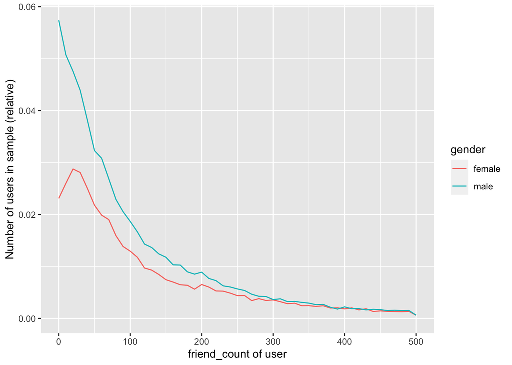

```r
## grah for friend_count < 500
qplot(data = na.omit(fb_data), x = friend_count, y=..count../sum(..count..), binwidth = 10, color = gender, geom = "freqpoly")+
  scale_x_continuous(limits = c(min(fb_data$friend_count),500))+
  xlab('friend_count of user') +
  ylab('Number of users in sample (relative)')
```

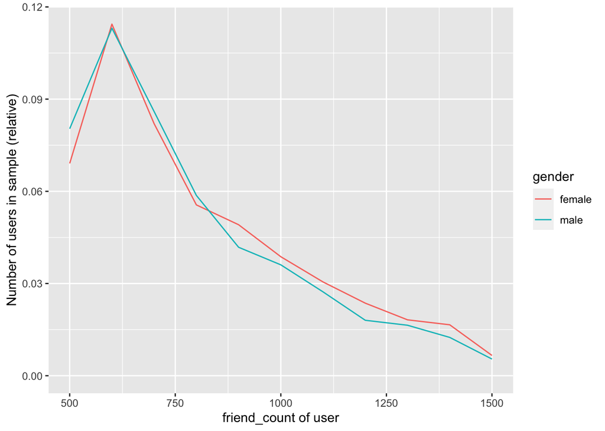

```r
qplot(data = na.omit(fb_data), x = friend_count, y=..count../sum(..count..), binwidth = 100, color = gender, geom = "freqpoly")+
  scale_x_continuous(limits = c(500 ,1500))+
  xlab('friend_count of user') +
  ylab('Number of users in sample (relative)')
```

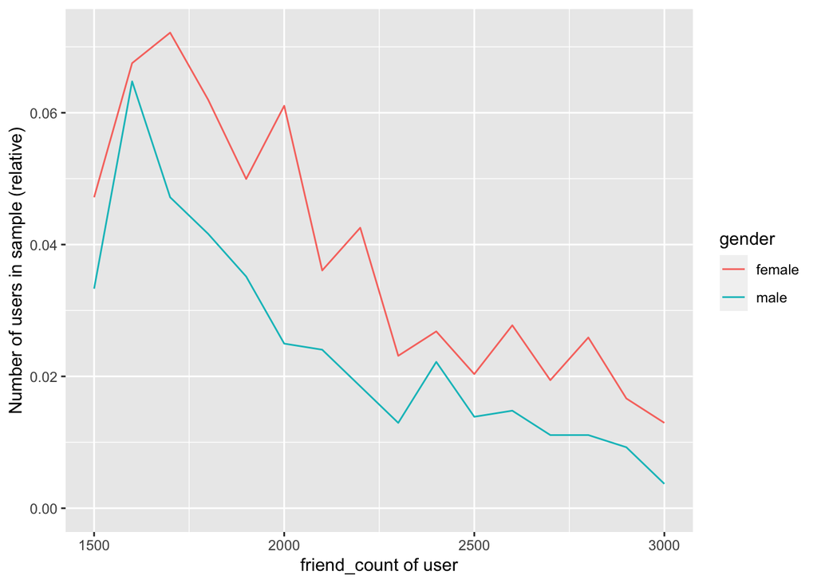

```r
qplot(data = na.omit(fb_data), x = friend_count, y=..count../sum(..count..), binwidth = 100, color = gender, geom = "freqpoly")+
  scale_x_continuous(limits = c(1500 ,3000))+
  xlab('friend_count of user') +
  ylab('Number of users in sample (relative)')
```

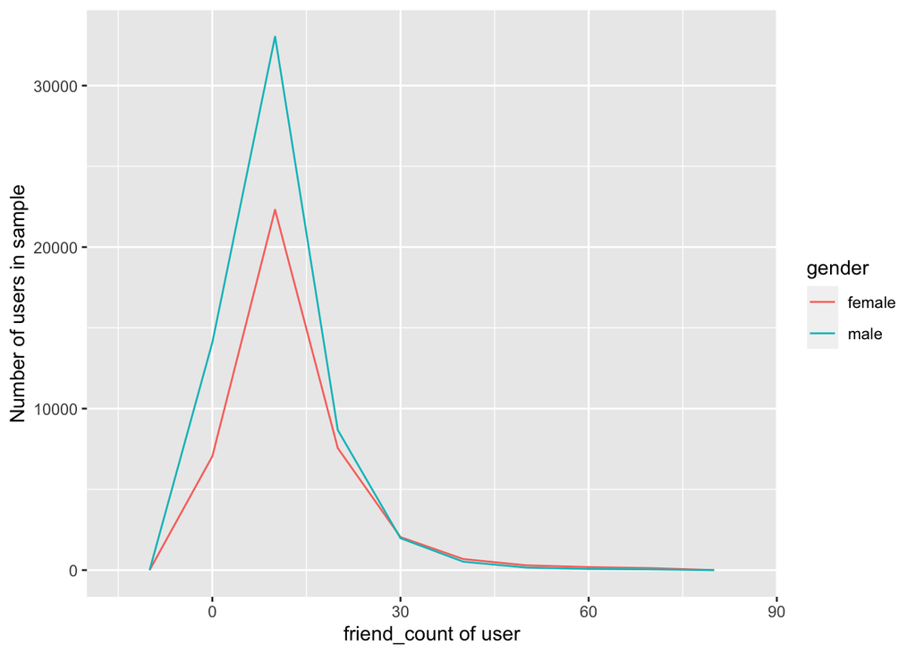

```r
qplot(data = na.omit(fb_data), x = sqrt(friend_count), binwidth = 10, color = gender, geom = "freqpoly")+
  xlab('friend_count of user') +
  ylab('Number of users in sample')
```

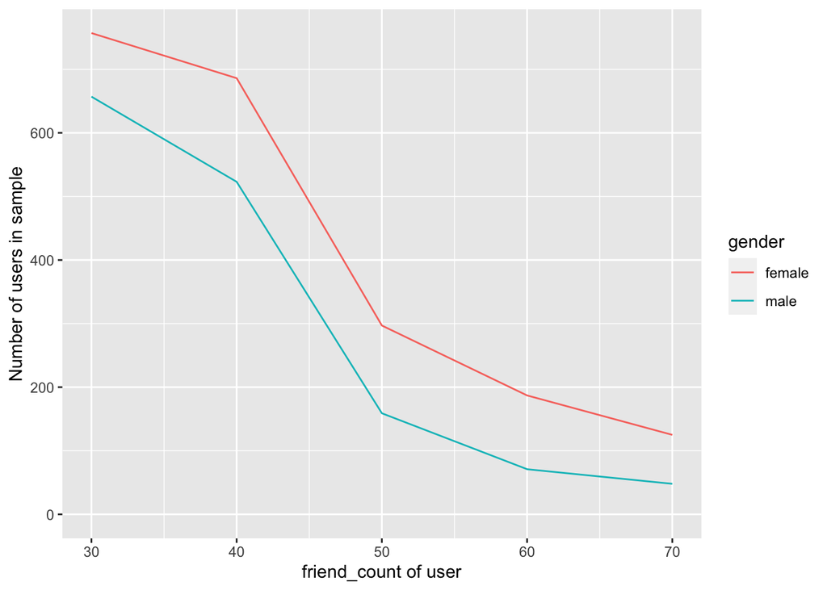

```r
qplot(data = na.omit(fb_data), x = sqrt(friend_count), binwidth = 10, color = gender, geom = "freqpoly")+
  scale_x_continuous(limits = c(30 ,70))+
  xlab('friend_count of user') +
  ylab('Number of users in sample')
```

### Likes on the Web

Notes:

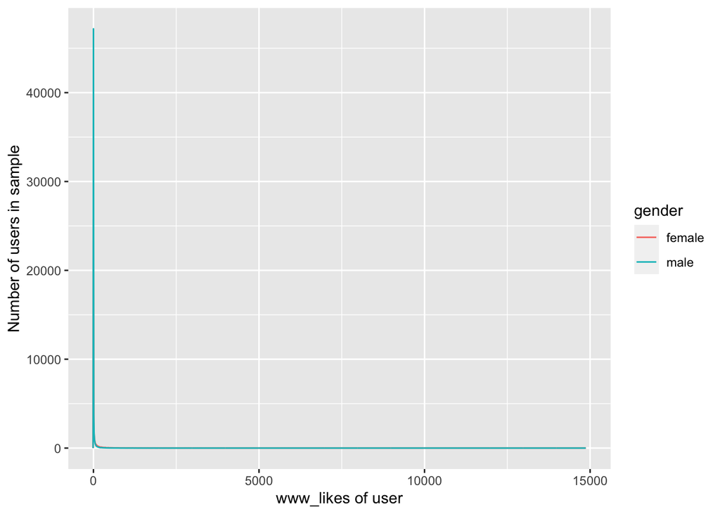

```r
qplot(data = na.omit(fb_data), x = www_likes, binwidth = 10, color = gender, geom = "freqpoly")+
  #scale_x_continuous(limits = c(min(fb_data$friend_count),max(fb_data$friend_count)))+
  xlab('www_likes of user') +
  ylab('Number of users in sample')
```

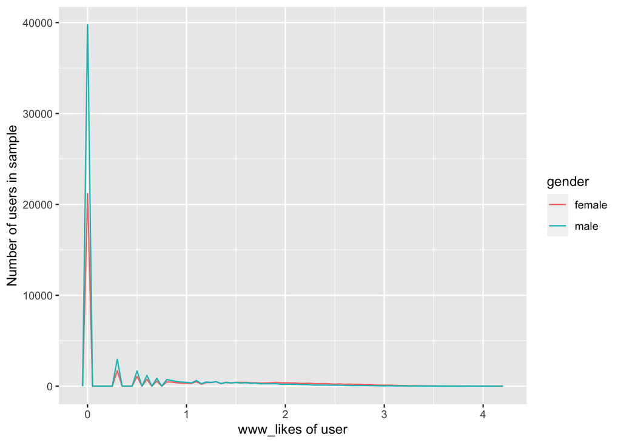

```r
qplot(data = na.omit(fb_data), x = log10(www_likes+1), binwidth = 0.05, color = gender, geom = "freqpoly")+
  #scale_x_continuous(limits = c(min(fb_data$friend_count),max(fb_data$friend_count)))+
  xlab('www_likes of user') +
  ylab('Number of users in sample')
```

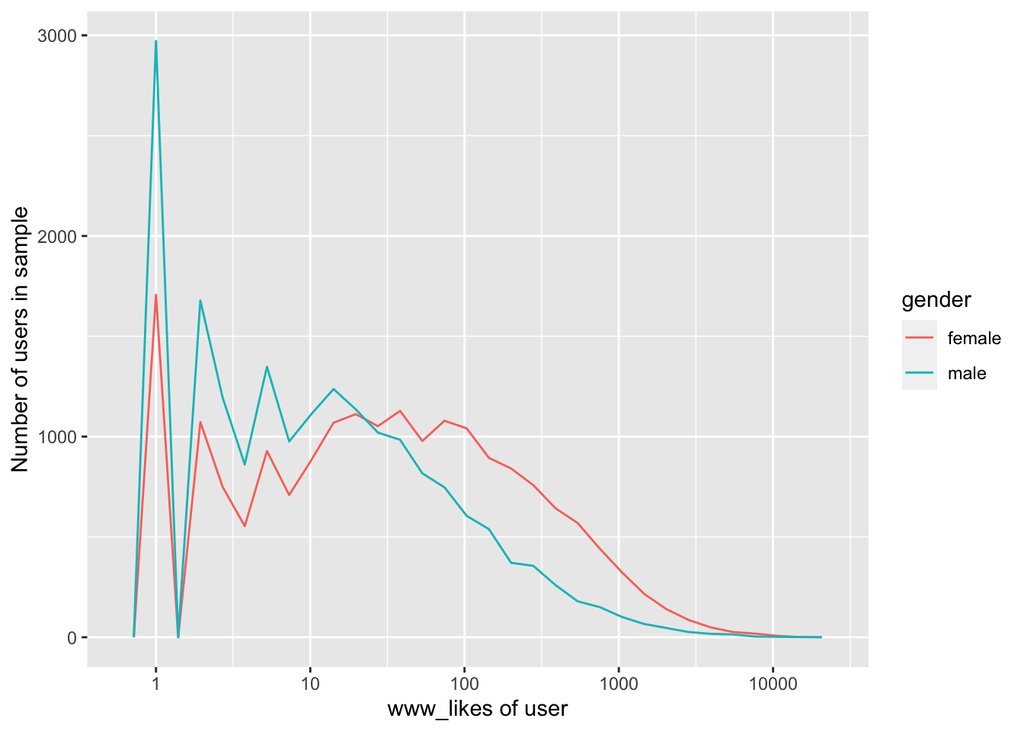

```r
qplot(data = subset(fb_data, !is.na(gender)), x = www_likes, color = gender, geom = "freqpoly")+
  scale_x_continuous(trans="log10")+
  xlab('www_likes of user') +
  ylab('Number of users in sample')
```

### whats the www_likes count for male?

```r
by(fb_data$www_likes, fb_data$gender, sum)
```

```
## fb_data$gender: female
## [1] 3507665
## --------------------------------------------------------
## fb_data$gender: male
## [1] 1430175
```

```r
by(fb_data$www_likes, fb_data$gender, summary)
```

```
## fb_data$gender: female
##     Min.  1st Qu.   Median     Mean  3rd Qu.     Max.
##     0.00     0.00     0.00    87.14    25.00 14865.00
## --------------------------------------------------------
## fb_data$gender: male
##     Min.  1st Qu.   Median     Mean  3rd Qu.     Max.
##     0.00     0.00     0.00    24.42     2.00 12903.00
```

### Box Plots

Notes:

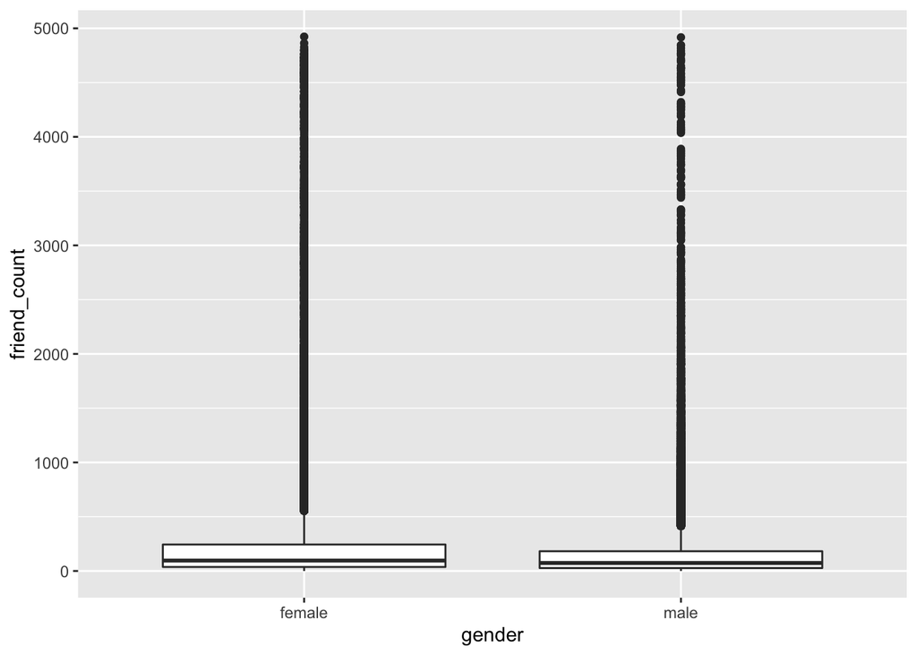

```r
qplot(data=subset(fb_data, !is.na(gender)), x= gender, y=friend_count, geom="boxplot")
```

#### Adjust the code to focus on users who have friend counts between 0 and 1000.

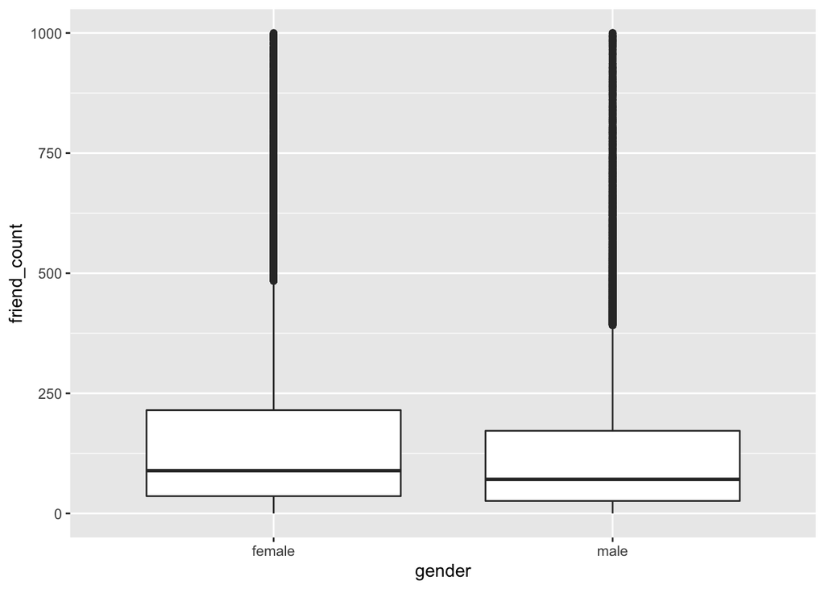

```r
qplot(data=subset(fb_data, !is.na(gender)), x= gender, y=friend_count, geom="boxplot")+
  scale_y_continuous(limits = c(0,1000))
```

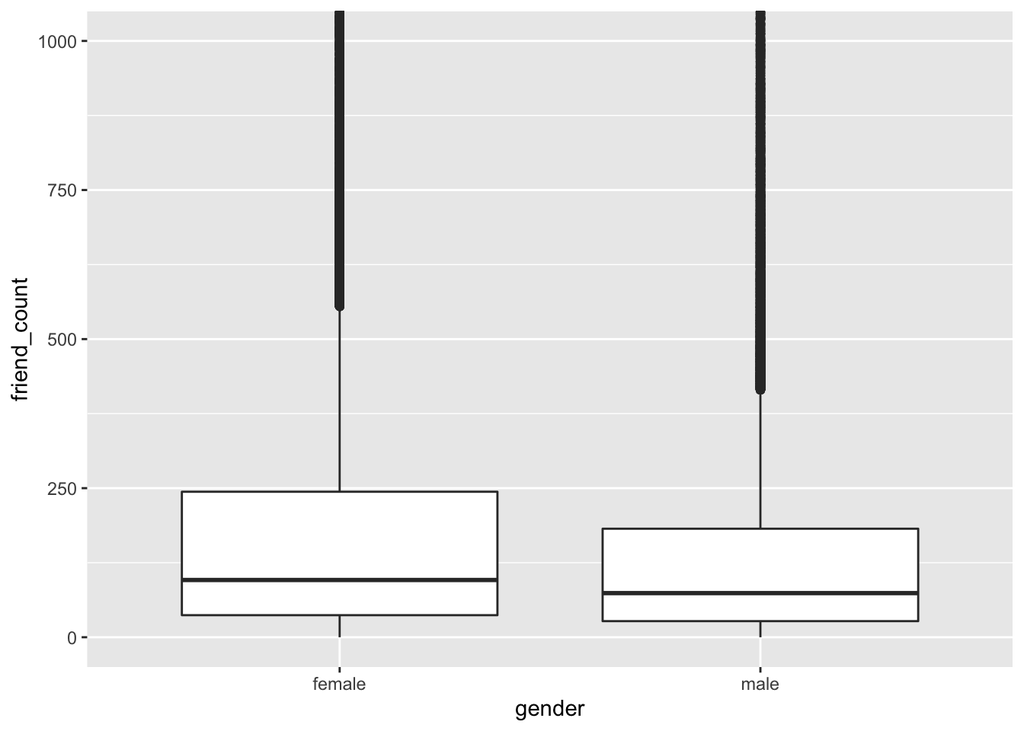

```r
qplot(data=subset(fb_data, !is.na(gender)), x= gender, y=friend_count, geom="boxplot")+
  coord_cartesian(ylim = c(0,1000))
```

### Box Plots, Quartiles, and Friendships

Notes:

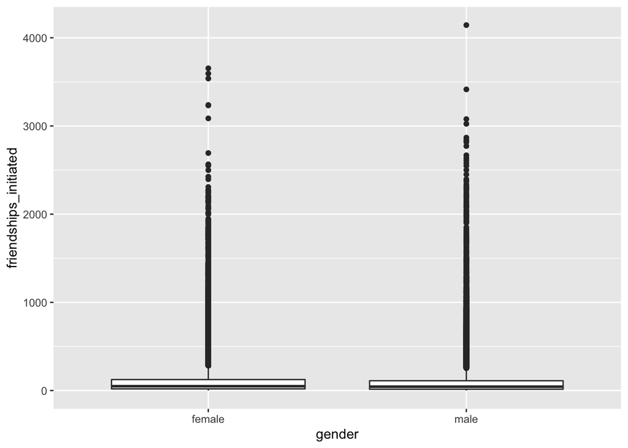

```r
qplot(data=subset(fb_data, !is.na(gender)), x= gender, y=friendships_initiated, geom="boxplot")
```

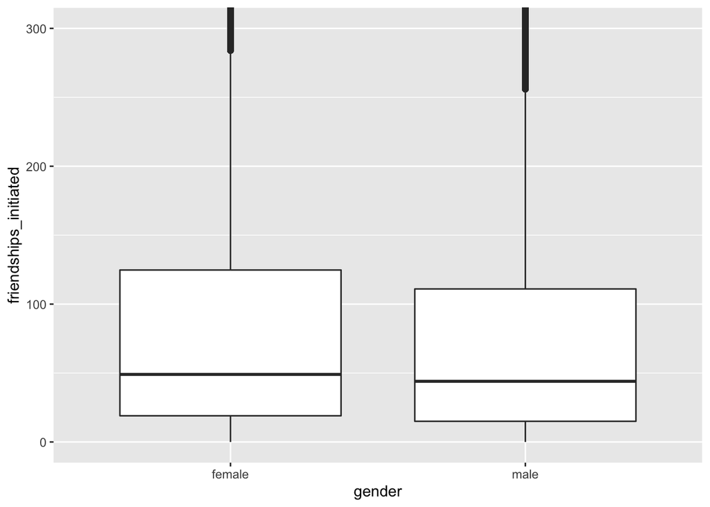

```r
  #coord_cartesian(ylim = c(0,1000))

qplot(data=subset(fb_data, !is.na(gender)), x= gender, y=friendships_initiated, geom="boxplot") +
  coord_cartesian(ylim = c(0,300))
```

```r
by(fb_data$friendships_initiated, fb_data$gender, summary)
```

```
## fb_data$gender: female
##    Min. 1st Qu.  Median    Mean 3rd Qu.    Max.
##     0.0    19.0    49.0   113.9   124.8  3654.0
## --------------------------------------------------------
## fb_data$gender: male
##    Min. 1st Qu.  Median    Mean 3rd Qu.    Max.
##     0.0    15.0    44.0   103.1   111.0  4144.0
```

#### On average, who initiated more friendships in our sample: men or women?

Response: female #### Write about some ways that you can verify your answer. Response: group column friendship_initiated by gender and take the average

```r
by(fb_data$friendships_initiated, fb_data$gender, mean)
```

```
## fb_data$gender: female
## [1] 113.8991
## --------------------------------------------------------
## fb_data$gender: male
## [1] 103.0666
```

Response:

### Getting Logical

Notes:

```r
cond = fb_data$mobile_likes > 0
fb_data$mobile_check_in <- ifelse(cond, 1, 0)
## factorize to define variable as categorical
fb_data$mobile_check_in <- factor(fb_data$mobile_check_in)

summary(fb_data$mobile_check_in) / length(fb_data$mobile_check_in)
```

```
##         0         1
## 0.3540903 0.6459097
```

Response:

### Analyzing One Variable

Reflection: - scale a variable could help to see pattern. therefore we use sqrt or a type of log function - to explore pattern we use some kind of plots. we have learned to use freqpoly, boxplots and histograms to analyse the distribution of a variable - sometimes variables distribution are “long tail”. with scaling and zooming into plots, more insights could be generated. it could help to transform a variable with lots of outliers in binary or multiple classes  
***

Click **KnitHTML** to see all of your hard work and to have an html page of this lesson, your answers, and your notes!